# C67 Report

### Question

Old Q: “Are there significant differences in professors’ salaries between men and women after accounting for academic rank, experience (years since obtaining a PhD, years of service), and discipline (theoretical/applied)?”

Is there an association between professors’ sex and salary after accounting for academic rank, experience (years since obtaining a PhD and years of service), and discipline (theoretical/applied), considering the unequal representation of male and female professors in the dataset?

### Multilinear regression and its residuals

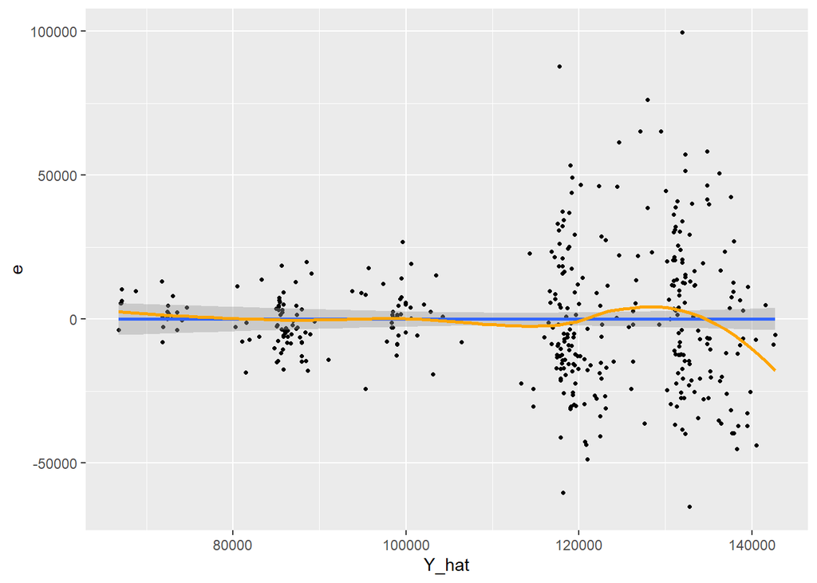

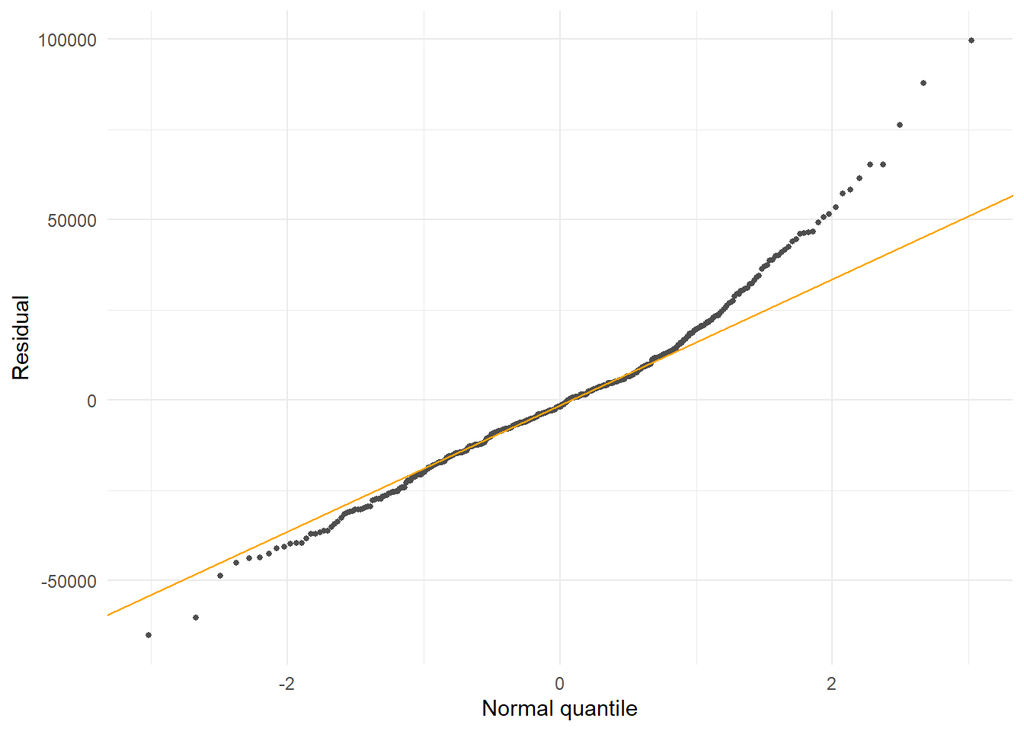

### Analysis of the Data

From our first model, we can see that men earn an estimated $4,800 more than women with other factors held constant, but the difference is not statistically significant (t = 1.24, p = 0.22). After accounting for rank, experience and discipline, the data show no significant salary difference between men and women. However, the standard error is $3,859 which is nearly as large as the estimate, so the gap is estimated imprecisely, and a real difference cannot be ruled out.

As for the residual analysis, there are some concerns. The residuals vs fitted plot shows no clear curvature, so Linearity (L) holds. According to our plots the spread looks like it grows from about ±$15,000 for assistant professors to ±$50,000 for full professors, so constant variance (E) is in doubt. The normal QQ plot follows the line in the centre, but its upper tail has a right skew, and the largest residual is about $100,000. Since the residuals are right-skewed, normality (N) is also in doubt.

#### Relationship between Salary (USD) and The Predicators

**Academic Rank:** Does salary differ between assistant, associate, and full professors? We find that full professors have considerably higher average salaries than assistant and associate professors, which shows that academic rank is an important predictor of professors’ salary. Notably, of the 266 full professors, 248 (93.2%) are male, while only 18 (6.8%) are female. Thus, the difference in academic rank distribution may help explain the initial salary gap between men and women. Therefore, we must carefully control for academic rank in regression

### Potential Data Issues

#### Unequal group size

The large differences within the group sizes may be affected due to significant differences between male and female professors. Out of the 397 total professors, there are 358 males and 39 females. Since there are significantly less female professors, the salary comparison can be less precise.

#### Multicollinearity

Multicollinearity may also have a role since some professors have higher years since they obtained a PhD and higher years of service. Those two predictors may create multicollinearity since both predictors give similar information about professors’ experience (correlation of 0.91 = strong positive linear relationship).

#### Potential outliers

This may affect the overall regression results due to unusually high or low salaries. Within the 397 salaries, we found three unusually high salaries, $204,000, $205,500 and $231,545, so we need to investigate whether these observations would influence the final regression.

#### Unusual observations

We observe considerable variability, as the data points are widely spread around the regression line. We also observe a trumpet-shaped pattern (trend), suggesting that the variance of the residuals may not be constant.

# 3. Model

## 3.1 Starting model

### Observations after 3.1

**Fit**: At least one predictor must be useful according to the F test (F = 54.2 on 6 and 390 df, p < 0.001). Additionally, the model explains only 45% of the variation in salary (R² = 0.455), with a large typical error (Residual Standard Error = $22,540). **Main drivers**: Rank matters most (Prof +$45,066 vs AsstProf), then discipline (applied +$14,418). Experience doesn’t add much on its own. **Sex**: the gap falls from -$14,088 unadjusted to -$4,784 after adjustment (p = 0.22). Most of the raw gap reflects women being concentrated in lower ranks, but we can’t conclude anything until the assumptions are checked. **Collinearity warning**: yrs.service has a negative slope (-$490) despite a positive correlation with salary, and the two experience slopes nearly cancel. Correlated predictors make coefficients unstable and can flip their signs, alluding to collinearity with yrs.since.phd (r = 0.91). **Assumption warning**: the residuals are right-skewed (max +$99,592 vs min -$65,248, median below 0).

## 3.2 Transforming the response

### Diagnostics of the starting model (Residual plots & Shapiro-Wilk Test):

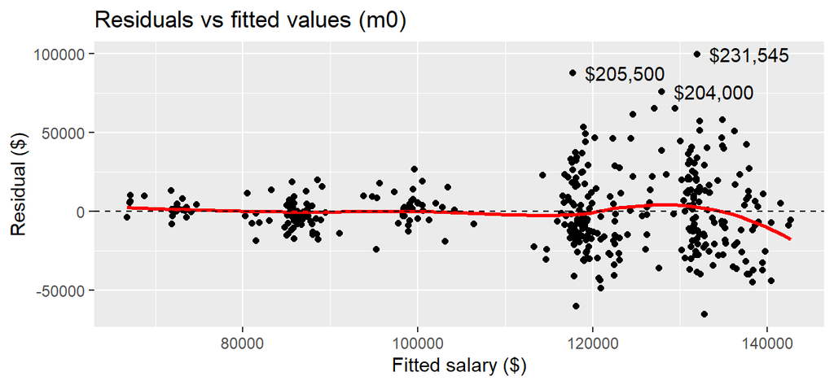

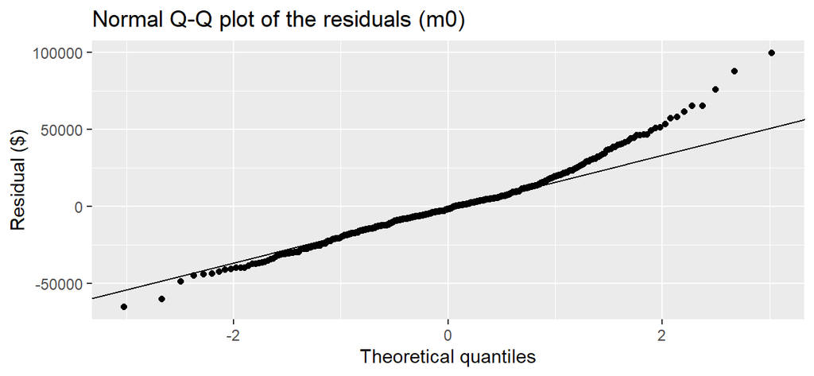

### Brown-Forsythe test (split on the fitted values):

**Residuals vs fitted**: Based on the salary ranges for each rank, the points seem to fall into clusters by rank. Assistant and associate professors have fitted values of about $70–105k, and full professors about $115–145k. The red line is flat, so *linearity* looks fine. The spread is much wider in the full-professor cluster (roughly ±$60k, against ±$20k for juniors), which is a funnel shape and questions *equal variance* (E). **Normal Q–Q**: the middle follows the line, but the upper tail bends above it. The three largest residuals, labelled with their salaries in the residuals vs fitted plot, are the three high salaries from [D1] ($231,545, $205,500 and $204,000), all full professors. Residuals are right-skewed, so *normality* (N) is questioned. **Shapiro–Wilk**: W = 0.969, p = 1.6×10⁻⁷. Reject normality. **Brown–Forsythe**: the high-fitted group’s mean absolute deviation is $21,983, against $10,869 for the low-fitted group, about twice as large. With t = 7.65 on 395 df and p = 1.6×10⁻¹³, reject *equal variance*.

**Conclusion**: the linearity assumption holds, but normality and equal variance fail. The pattern is right skew with spread growing as salary rises, which is a sign that the response needs a transformation. That justifies a Box-Cox step next.

Box-Cox (read $\hat{\lambda}$ and its 95% CI off the plot):

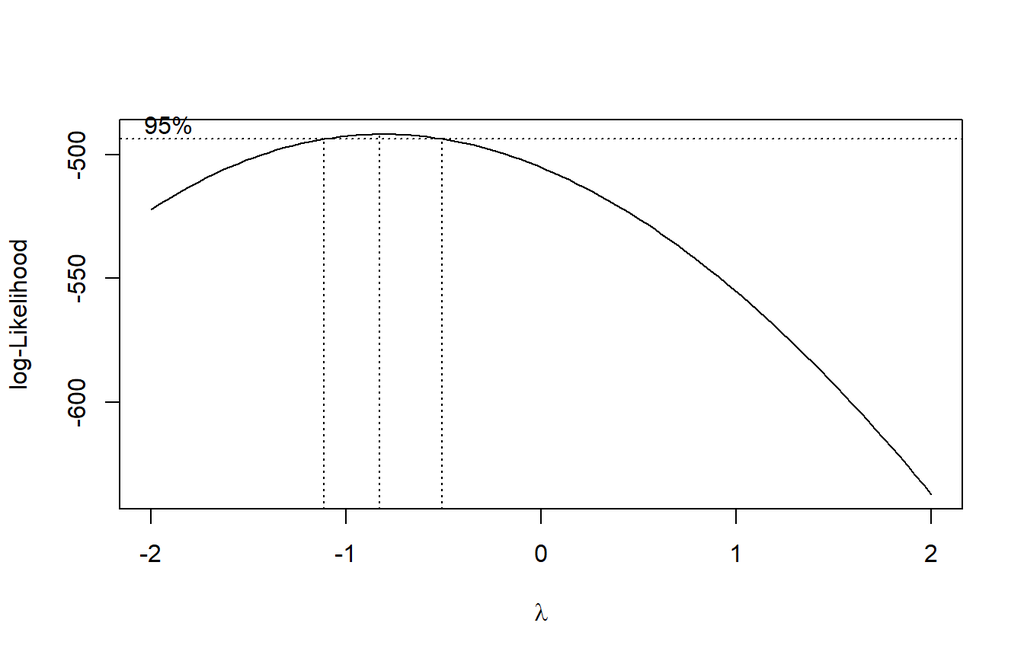

The Box-Cox plot shows that the 95% CI for lambda is roughly (-1.1, -0.5), which does not include 0 (log/ln) or 1 (no transformation), but does contain -1 (reciprocal). Because the skew and growing spread are the pattern for which ln Y is recommended, and because log coefficients give the sex effect as a percentage difference, we will compare ln Y with the reciprocal (λ = -1, inside the CI).

Comparing log(salary) and 1/salary:

|  | No transformation (m0) | log(salary) (m1) | 1/salary (mr) |
| --- | --- | --- | --- |
| Shapiro–Wilk p | 1.6×10⁻⁷ | 0.022 | 1.8×10⁻⁵ |
| Brown–Forsythe p | 1.6×10⁻¹³ | 3.3×10⁻⁶ | 0.10 |
| Residual SD, Prof ÷ AsstProf | 3.76 | 2.56 | 1.72 |

We compared log(salary) with 1/salary, the reciprocal that lies inside the interval. The log gave clearly more normal residuals (Shapiro–Wilk p = 0.022 vs 1.8×10⁻⁵), and its coefficients read as percentage differences. The reciprocal gave more constant variance (Brown–Forsythe p = 0.10 vs 3.3×10⁻⁶).

So, we adopt log(salary). It corrects the skew and makes the residuals roughly symmetric, but equal variance is still violated, mainly because full professors’ salaries vary more than other ranks’. We choose log over the reciprocal because it gives more normal residuals, interpretable coefficients, is typical for salaries, and has been discussed more in lecture.

## 3.3 Polynomial terms

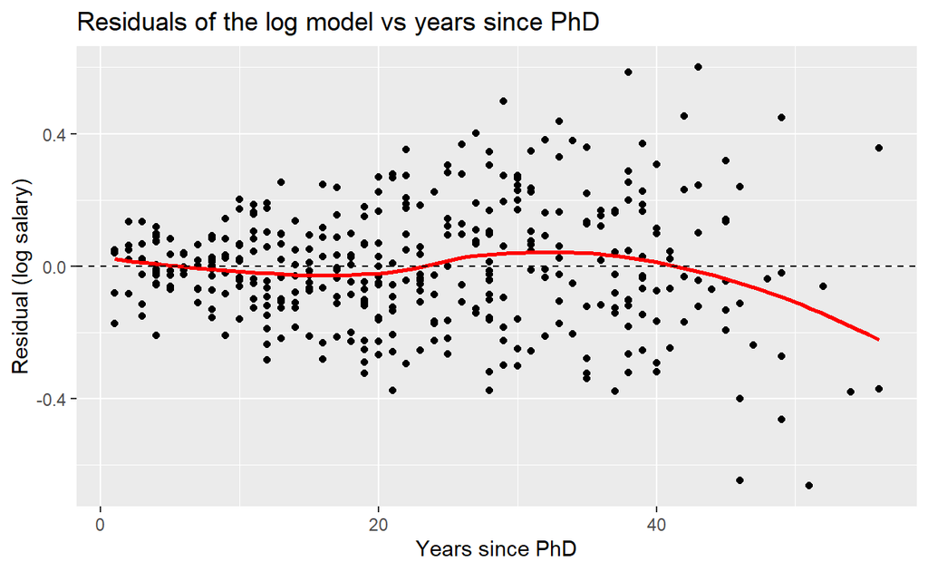

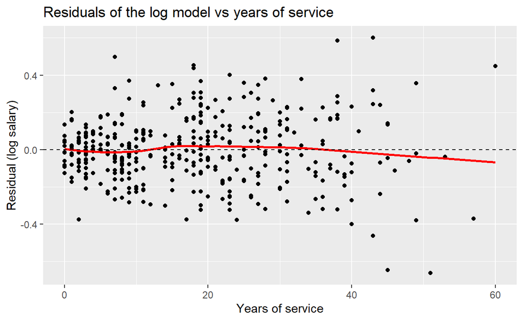

In the log model, the lowess trend of residuals against yrs.since.phd is flat for about 30 years and then curves down. The trend for yrs.service is mostly flat. Under the class rule, a curve in residuals against a predictor means linearity fails for that predictor.

So, we add a centred quadratic term (phd.c²), keeping phd.c in the model. A partial F test confirms it (F = 6.96, p = 0.009), while service² is not needed (p = 0.86).

Centring cut the correlation between yrs.since.phd and its square from 0.96 to 0.27, removing most of the collinearity between the two terms without changing the fit.

## 3.4 Interactions

Interactions with sex:

We tested whether the gender gap differs across groups by adding each sex interaction to the model with phd² and comparing them with partial F tests. None was significant: sex × rank (F = 0.43, p = 0.65), sex × discipline (F = 1.73, p = 0.19), sex × yrs.since.phd (p = 0.97) and sex × yrs.service (p = 0.99). With only 4–10 women in each rank × discipline group, these tests have little power. The results show no evidence that the gap varies, not proof that it is constant.

Other interactions:

## 3.5 Overlap between yrs.since.phd and yrs.service

yrs.since.phd and yrs.service are highly correlated (r = 0.91), with VIFs of 7.5 and 5.9. These are below 10 but well above 1, which together with the opposite-signed slopes indicates moderate collinearity confined to the experience variables. We keep both because the research question names both. Collinearity inflates their standard errors without biasing the estimates, and it doesn’t affect the sex coefficient (VIF 1.03).

## 4.1 Model selection

### Automatic search procedures

- **With the AIC, the three searches agree.** Backward elimination removes five interactions (serv.c × rank, sex × yrs.service, sex × rank, sex × yrs.since.phd and rank × discipline). Forward selection and stepwise regression build up the same model, and all three end at AIC = -1360.56 with phd.c, phd.c², serv.c, sex, rank, discipline, sex × discipline and phd.c × rank. Stepwise regression never removes a term on the way, so it ends where forward selection does.
- **With the BIC, the three searches also agree, but keep only rank and discipline.** BIC charges ln 397 = 5.98 per parameter instead of 2, so it chooses a much smaller model.

The BIC model cannot be used as it stands. It removes sex and both experience variables, but our question asks about sex *after accounting for* rank, both experience variables and discipline, so these five variables must stay in the model whatever the criteria say. The criteria rank models; they do not know the question. The AIC model keeps all five variables and every lower-order term, so it is one of our candidates.

So we keep the five variables of the question in every model and compare a few candidates built from the search paths:

- **A**: the five variables and phd.c², which is model m2 of 3.3.
- **B**: A plus phd.c × rank. This is where forward selection stands one step before it stops.
- **C**: B plus sex × discipline. This is where all three AIC searches stop.
- **D**: C plus rank × discipline. This is where backward elimination stands one step before it stops.

### Criteria for the candidate models

| Candidate | Optional terms added | p | Adjusted R² | Cp | AIC | BIC | PRESS | Best of the six by |
| --- | --- | --- | --- | --- | --- | --- | --- | --- |
| — | none | 7 | 0.5175 | 17.31 | −1351.4 | −1323.5 | 13.196 |  |
| A | phd.c² | 8 | 0.5248 | 12.28 | −1356.5 | **−1324.6** | 13.106 | BIC |
| B | phd.c², phd.c × rank | 10 | 0.5318 | 8.45 | −1360.4 | −1320.6 | 12.938 |  |
| C | phd.c², phd.c × rank, sex × discipline | 11 | 0.5331 | **8.39** | **−1360.6** | −1316.7 | 12.905 | Cp, AIC |
| D | phd.c², phd.c × rank, sex × discipline, rank × discipline | 13 | **0.5332** | 10.31 | −1358.7 | −1306.9 | **12.895** | adjusted R², PRESS |
| — | all eight (full model) | 19 | 0.5299 | 19.00 | −1350.2 | −1274.5 | 13.004 |  |

- Every criterion prefers A to the model without phd.c², which confirms 3.3. Without phd.c², Cp = 17.3, far above p = 7: a sign of bias ([L18]).
- None of the candidates contains sex × rank, sex × yrs.since.phd or sex × yrs.service. All three AIC searches left them out, which agrees with 3.4.
- The criteria disagree about phd.c × rank, sex × discipline and rank × discipline. The differences are small: adjusted R² goes from 0.525 to 0.533, and PRESS from 13.11 to 12.90 (about 1.6%).

## 4.2 Final model

**Choice: model A.** It is the model chosen by BIC and the simplest candidate, and the other criteria improve on it only slightly (PRESS 13.11 against 12.90, adjusted R² 0.525 against 0.533). It also answers the question with a single sex gap.

- B, C and D add phd.c × rank, which lets salaries rise with experience at different rates in each rank. It improves the fit only slightly, and it is not needed to answer our question about the sex gap.
- C and D also add sex × discipline, which would let the gap differ between theoretical and applied departments. This interaction was not significant in 3.4 (F = 1.73, p = 0.19), so we report one gap for both.

Following lecture, we prefer the simpler model when the candidates are nearly as good.

Model A answers the question best because it holds fixed every variable the question names (rank, both experience measures and discipline), uses log salary and a squared PhD term so its assumptions hold well enough for the sex test to be trusted, and is the simplest of the nearly equally good candidates. Its single sex coefficient is the gap between otherwise identical men and women, and we found no evidence that this gap differs across groups.

Model A is exactly model m2 of 3.3, fitted on all 397 professors.

### Limitations/Considerations

- **One gap for both disciplines.** The model preferred by AIC and Cp (C) suggests that the gap may be larger in theoretical departments (-9.3%, p = 0.031) than in applied ones (-1.0%). The difference between the two is not significant (p = 0.15), but with only 4–10 women in each rank × discipline group, these data have little power to show it.
- **No separate validation set.** For consistency with the rest of the report, model selection and the final fit both use all 397 professors. The chosen model was picked because it fits these data well, so its R² and p-values are somewhat optimistic, and how well it predicts new professors has not been checked on data kept aside, for instance with a training/validation split and the MSPE. PRESS, which predicts each professor from a fit that leaves that professor out, gives a partial check.

## 5. Validation

In this step, we will check the assumptions of our final model with the residual plots, looking for outlying and influential observations, multicollinearity and discuss the remedial measures taken.

### 5.1 Residual Analysis

Below, from left to right, is the residuals vs fitted and the Q-Q plot

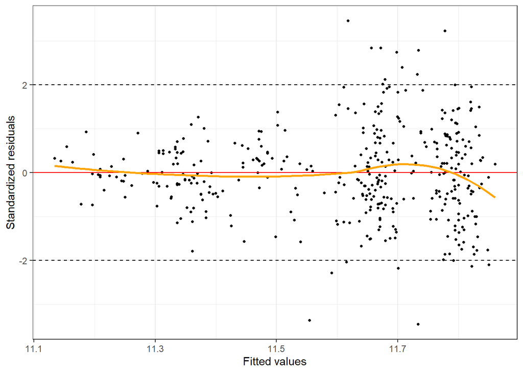

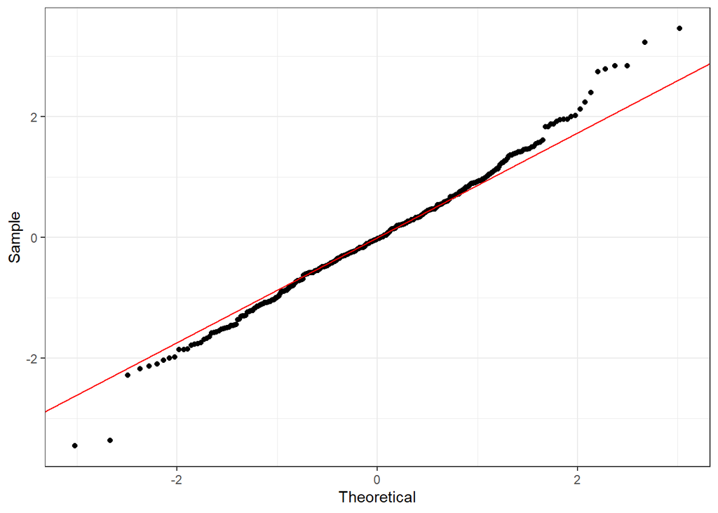

**Linearity and constant variance:** The standardized residuals are centered around the zero across the range of fitted values, and the loess curve stays close to zero except for a small downward bend at the far right. There are only a few observations here, this no strong evidence that the mean structure is misspecified. Overall, the linear form of the model looks adequate. The spread of residuals is not constant as it is noticeably larger for the higher fitted values compared to the lower and almost all points +/- 2 are in the right half of the plot. This is a mild violation of constant variance and means that standard errors and p-values should be read with some caution

**Normality:** In the Q-Q plot, the points follow the line closely in the middle, with the tails deviating from it. The errors this have somewhat heavier tails than a normal distribution, with a few large residuals. With 397 observations, these are mild problems as the estimates of the coefficients remain unbiased.

### 5.2 Observations

#### 5.2.1 Outlying observations

The five most extreme observations

| Observation | Studentized deleted residual |
| --- | --- |
| 365 | 3.51 |
| 318 | -3.51 |
| 283 | -3.41 |
| 44 | 3.27 |
| 351 | 2.87 |

The Bonferroni cutoff is |t| > 3.87, and the largest value in the data is 3.51. 0 observations exceed the cutoff, so there are no outliers in the response. These points are consistent with the slightly heavy tails seen in the Q-Q plot.

#### 5.2.2 High leverage (unusual predictors)

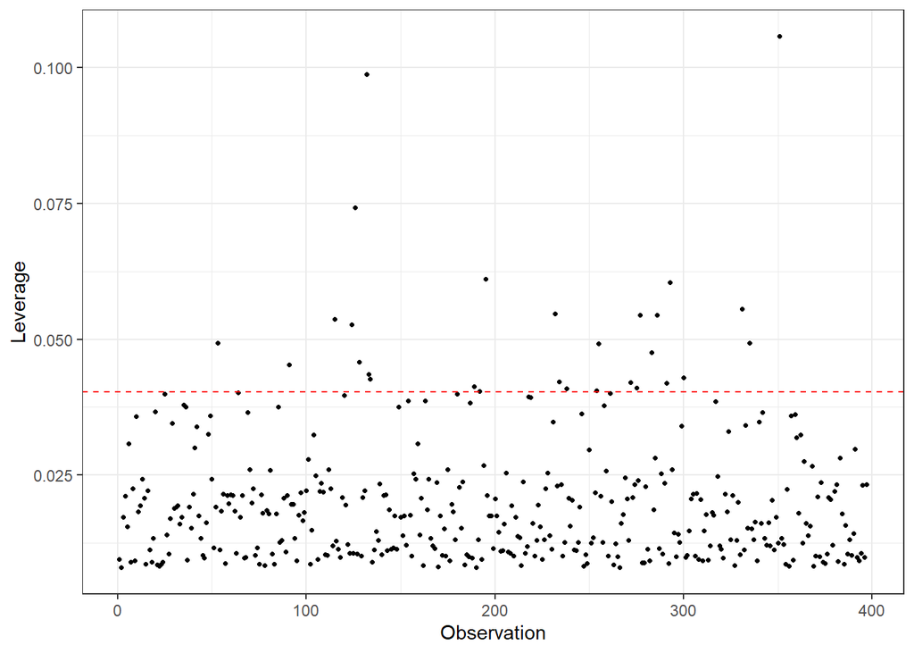

28 of the 397 observations have leverage above 2p/n = 0.04 (maximum 0.106). This means their combination of rank, discipline, experience and sex is less typical than most. Only a few points stand out clearly and the largest leverage is about 2.6 times the cutoff. High leverage by itself does not mean a point distorts the fit but only means it has potential to. Thus we must assess the influence next.

#### 5.2.3 Influential observations: Cook’s distance

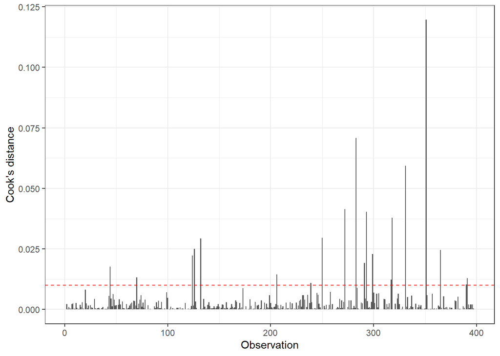

20 observations have Cook’s distance above 4/n = 0.0101 (maximum 0.12). However, 4/n is only a screening rule and the largest Cook’s distance is 0.12, far less than 1. This is the level when a single observation is considered to have a large effect on the fit. Most of the larger values are in a small group of observations rather than spread out. No single professor dominates the model, but the group of 20 together could affect the estimate of sex. Thus, we will examine this next.

#### 5.2.4 Does the conclusion about sex change without the influential points?

|  | Estimate | Std. Error | t value | Pr(>\|t\|) |
| --- | --- | --- | --- | --- |
| All data | -0.0520 | 0.0308 | -1.6891 | 0.0920 |
| Influential points removed | -0.0277 | 0.0267 | -1.0366 | 0.3006 |

With the 20 flagged observations removed, the estimate for sex changes from -0.052 (p = 0.092) to -0.028 (p = 0.301). In both fits, the p-value is above 0.05. Thus, our conclusion is unchanged. We do not find a significant difference between men’s and women’s salaries after accounting for rank, experience and discipline. The influential points were making the estimated gap look larger. So, without them, it is closer to zero and even less significant. This suggests that our conclusion is not driver by unsual observations. In conclusion, we keep all 397 observations in the final model as there is no evidence that ay of them cause data errors.

### 5.3 Multicollinearity

Multicollinearity occurs when predictors have a strong correlation with each other. This makes it difficult to asses the individual effect of each predictor, as it makes the estimates unstable. What allows us to check for multicollinearity is the variance inflation factor (VIF) for each individual variable in Model A.

| Predictor | GVIF | Df | $\text{GVIF}^{1/(2 \cdot \text{Df})}$ |
| --- | --- | --- | --- |
| phd.c | 8.59 | 1 | 2.93 |
| phd.c$^2$ | 2.42 | 1 | 1.56 |
| serv.c | 6.13 | 1 | 2.48 |
| sex | 1.04 | 1 | 1.02 |
| rank | 4.33 | 2 | 1.44 |
| discipline | 1.06 | 1 | 1.03 |

Quick Note: GVIF is the VIF exactly when Df = 1.  
Within the lectures, it is mentioned that a VIF above 10 is when multicollinearity becomes a serious issue.

In our data, the years since obtaining a PhD and years of service have a strong correlation ($r = 0.91$). However, in the model chosen (model A), both predictors stay under a VIF of 10 (8.59 and 6.13 respectively). All other comparable VIFs are well below a VIF of 10 (with an overall average of 3.93).

Looking back to section 3.5, the VIFs for phd.c and serv.c (8.59 & 6.13) increased (compared to 7.5 & 5.9) when $phd.c^2$ was added to the model.

### 5.4 Remedial Measures Taken

Multiple Remedial Measures were taken: